# Lecture 10: Styling ggplot2

Nick Huntington-Klein

17 June, 2022

## Styling ggplot

- We should have a decent idea at this point of how to put a **ggplot2** graph together
- But how do we make it look good?

## Today!

- We’ll talk about how to set aesthetic attributes along every axis
- As well as overall styling and theming
- Highlighting, putting graphs together, making them interactive, annotating…
- **Think about this stuff**. Your graphs will look unprofessional if you don’t, and I’ll start grading down all-default styling or missed opportunities for improvement.

## Aesthetic Characteristics

- As you’d expect, we’ll be setting the values of certain aesthetic properties
- Which ones apply depend on the geometry. See [this page](https://ggplot2.tidyverse.org/articles/ggplot2-specs.html). Some common ones:
- color, linetype, fill, size, shape (and soon: linewidth)
- Text aesthetics: family (font), fontface, hjust, vjust (see **extrafont** package to use all your system fonts)

## Decorating Axes vs. Decorating Geometries

- When a characteristic is set *inside* of an `aes()`, it becomes an axis and must be mapped to a variable name
- *Outside* of an `aes()` (and in the geometry), it’s a setting applied to the entire geometry

## Aesthetic Characteristics

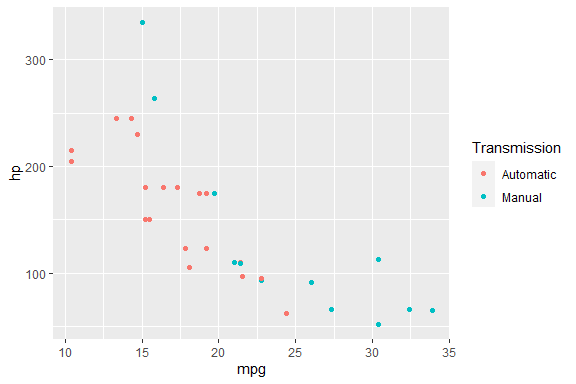

```r
# We've seen this before
mtcars <- mtcars %>%
  mutate(Transmission = factor(am, labels = c('Automatic','Manual')))
ggplot(mtcars, aes(x = mpg, y = hp, color = Transmission)) +
  geom_point()
```

## Aesthetic Characteristics

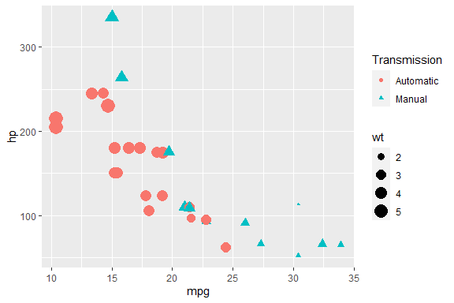

```r
ggplot(mtcars, aes(x = mpg, y = hp, color = Transmission,
                   size = wt, shape = Transmission)) +
  geom_point()
```

## Aesthetic Characteristics

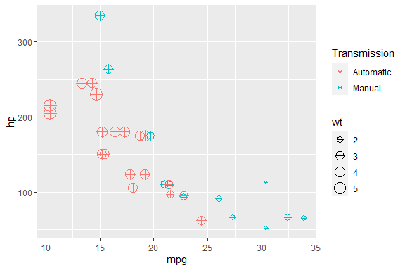

```r
ggplot(mtcars, aes(x = mpg, y = hp, color = Transmission,
                   size = wt)) +
  geom_point(shape = 10)
```

## Aesthetic Characteristics

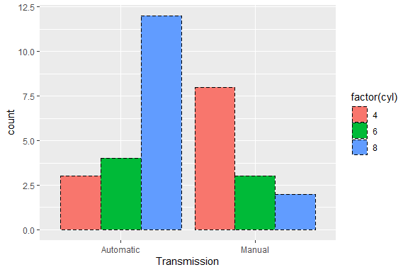

```r
ggplot(mtcars, aes(x = Transmission, fill = factor(cyl))) +
  geom_bar(position = 'dodge', linetype = 'dashed', color = 'black')
```

## Coordinates

- Everything *behind* the geometries can be manipulated as well
- For example, we can change the coordinate system (usually to `coord_flip` it for bar graphs)

## Coordinates

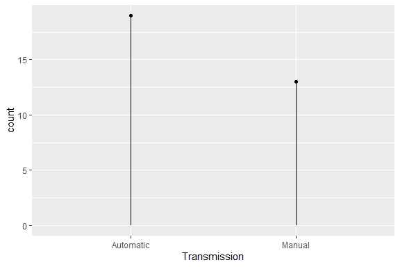

```r
library(ggalt)
mtcars2 <- mtcars %>% group_by(Transmission) %>% summarize(count = n())
ggplot(mtcars2, aes(x = Transmission,y=count)) + geom_lollipop()
```

## Coordinates

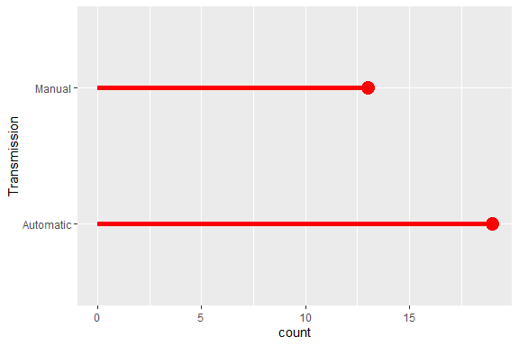

```r
# geom_lollipop in particular has a 'horizontal' option anyway
# so this is just for demonstration
ggplot(mtcars2, aes(x = Transmission,y=count)) +
  geom_lollipop(color = 'red', size = 2) + coord_flip()
```

## Axes

- We can control axis text with `axis.text` and the ticks we mark on the `scale`
- `element_text` provides text objects

```r
ggplot(mtcars2, aes(x = Transmission,y=count)) +
  geom_lollipop(color = 'red', size = 2) + coord_flip() +
  labs(x = '', y = '') +
  scale_y_continuous(breaks = c(10,20), limits = c(0,20)) +
  theme(axis.text.x = element_text(size = 12,family='serif'),
        axis.text.y = element_text(size = 16,family='serif', angle = 10))
```

## Axes

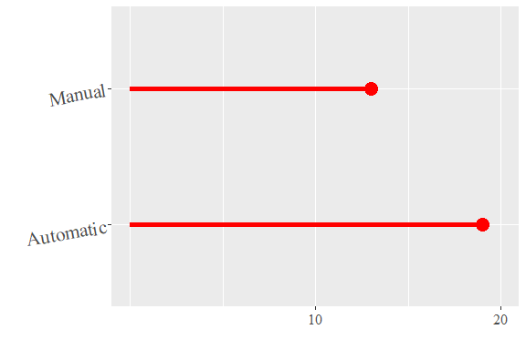

## Axes

- Order for discrete axes can be changed with `limits`

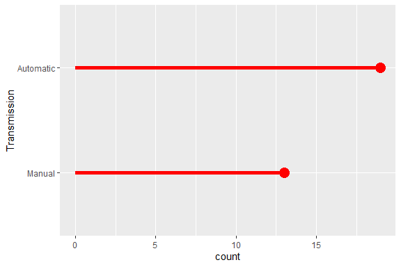

```r
ggplot(mtcars2, aes(x = Transmission,y=count)) +
  geom_lollipop(color = 'red', size = 2) + coord_flip() +
  scale_x_discrete(limits = c("Manual", "Automatic"))
```

## Theming

- Pretty much all elements of presentation that aren’t in a geometry can be controlled with `theme()`
- The options are endless! See `help(theme)`
- We set different aspects of the theme using `element_` functions like `element_text()`, `element_line()`, `element_rect()` which take aesthetic settings like `size`, `color`, etc.

## Axes

- Change axis and tick lines with `axis.line` and `element_line`
- Most everything can be changed generally (`axis.line` or even `line`) or specifically (`axis.ticks.x`)

```r
ggplot(mtcars2, aes(x = Transmission,y=count)) +
  geom_lollipop(color = 'red', size = 2) + coord_flip() +
  labs(x = '', y = '') +
  scale_y_continuous(breaks = c(10,20), limits = c(0,20)) +
  theme(axis.line = element_line(color = 'red'),
        axis.ticks.x = element_line(size = 5))
```

## Axes

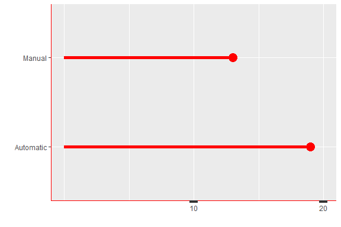

## Background

- Work on the `panel` to change what goes behind that geometry! `element_rect` might come up!
- Pretty much ANY element can be eliminated with `element_blank()`
- This gonna be ugly

```r
ggplot(mtcars2, aes(x = Transmission,y=count)) +
  geom_lollipop(color = 'red', size = 2) + coord_flip() +
  theme(panel.background = element_rect(color = 'blue', fill = 'yellow'),
        panel.grid.major.x = element_line(color = 'green'),
        panel.grid.major.y = element_blank())
```

## Background

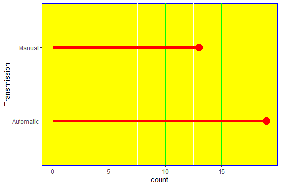

## Legends

- We showed a bit last time how legends can be changed.
- Note in `element_text` (and elsewhere, like annotation or `geom_text`), `hjust` and `vjust` align text horizontally and vertically. Set 0/1 for L/R or Top/Bottom
- `legend.position` is in portion of the frame. .8 = 80% to the right.

```r
ggplot(mtcars, aes(x = mpg, y = hp, color = Transmission)) + geom_point() +
  theme(legend.text = element_text(hjust = .5, family = 'serif'),
        legend.title = element_text(hjust = 1, family = 'serif', face = 'bold'),
        legend.background = element_rect(color = 'black', fill = 'white'),
        legend.position = c(.8,.7))
```

## Legends

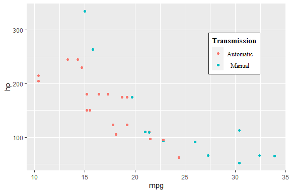

## Themes

- The theme is immensely flexible. We didn’t even cover everything, like the plot title/caption
- You can save your `theme()` settings as an object to use repeatedly as a house style
- Or use a prepackaged one! You can even tack on more `theme()` customization afterwards.
- Many `theme_` settings you can tack on. I only use a few…
- (many many others… want to look like FiveThirtyEight or The Economist? Check **ggthemes**)

## Prepackaged Themes: Default

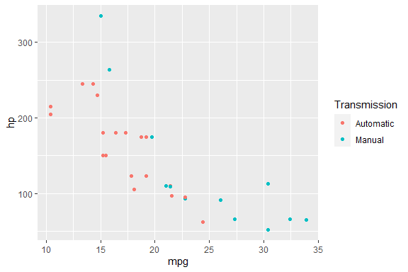

```r
ggplot(mtcars, aes(x = mpg, y = hp, color = Transmission)) + geom_point()
```

## Prepackaged Themes: Classic

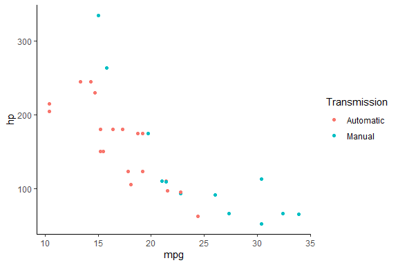

```r
ggplot(mtcars, aes(x = mpg, y = hp, color = Transmission)) + geom_point() +
  theme_classic()
```

## Prepackaged Themes: void (for things like flowcharts)

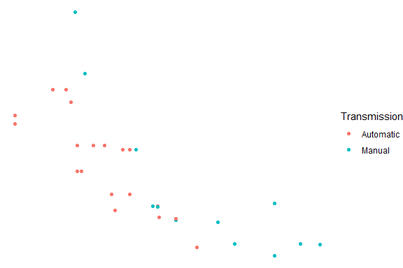

```r
ggplot(mtcars, aes(x = mpg, y = hp, color = Transmission)) + geom_point() +
  theme_void()
```

## Prepackaged Themes: tufte (in ggthemes)

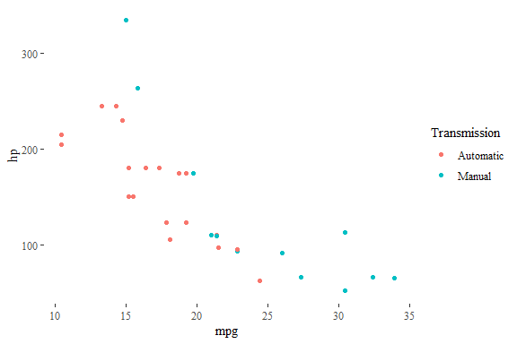

```r
library(ggthemes)
ggplot(mtcars, aes(x = mpg, y = hp, color = Transmission)) + geom_point() +
  theme_tufte()
```

## Prepackaged Themes: theme_pubr (in ggpubr), my go-to

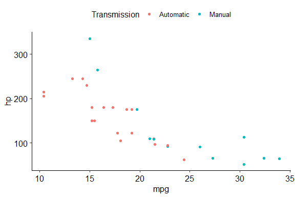

```r
ggplot(mtcars, aes(x = mpg, y = hp, color = Transmission)) + geom_point() +
  theme_pubr()
```

## General Theming Notes

- How can we think about theming generally?
- We want, as always, to drive focus towards our story
- This means not making the theme distracting it, but using it to drive attention to what we want
- Need focus on the x-axis labels? Make em bold!
- Often we don’t need distracting background color (as there is in the default theme). Usually get rid of it!

## Other Styling

- Let’s move on to some other ways we can build focus and clarity
- Highlight and annotations!

## Highlighting

- Highlight certain values and gray others with the **gghighlight** package

```r
library(gghighlight); data(gapminder, package = 'gapminder')
ggplot(gapminder, aes(x = year, y = lifeExp, color=country)) + geom_line(size = 1.5) +
  labs(x = NULL, y = "Life Expectancy", title = "North America Only") +
  scale_x_continuous(limits=c(1950,2015),
                     breaks = c(1950,1970,1990,2010))+
  gghighlight(country %in% c('United States','Canada','Mexico'),
              unhighlighted_params = aes(size=.1),
              label_params=list(direction='y',nudge_x=10)) +
  theme_minimal(base_family='serif')
```

## Highlighting

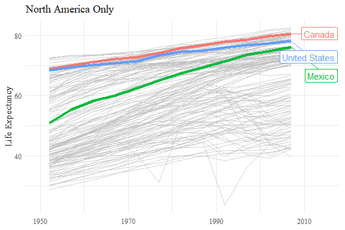

## Highlighting

- Or do it manually with `scale_X_manual()`

```r
gapminder %>% mutate(color_name = ifelse(country %in% c('United States','Canada','Mexico'), as.character(country), 'Other')) %>%
ggplot(aes(x = year, y = lifeExp, group = country, color=color_name, size = color_name, alpha = color_name)) + geom_line() +
  geom_text(aes(label = ifelse(year == 2007 & color_name != 'Other', color_name,'')),
                           hjust = 0, size = 13/.pt) +
  labs(x = NULL, y = "Life Expectancy", title = "North America Only") +
  scale_x_continuous(limits=c(1950,2025),
                     breaks = c(1950,1970,1990,2010))+
  scale_color_manual(values = c('red','forestgreen','gray','blue')) +
  scale_size_manual(values = c(1.5,1.5,.1,1.5)) +
  scale_alpha_manual(values = c(1,1,.2,1)) +
  theme_minimal(base_family='serif') +
  guides(color = 'none', size = 'none', alpha = 'none')
```

## Highlighting

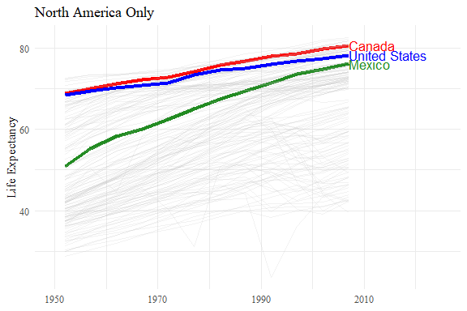

## Annotation

- There are also many options for *annotating* our data
- For direct data point annotation, especially of line graphs, you can do this with some data manipulation and `geom_text` (see previous slide)
- For putting a block of text I recommend **ggannotate**
- I also recommend looking into [**ggtext**](https://wilkelab.org/ggtext/) which allows rich-text formatting of all text on the graph, but we won’t be covering it here.

## Direct Line Labels

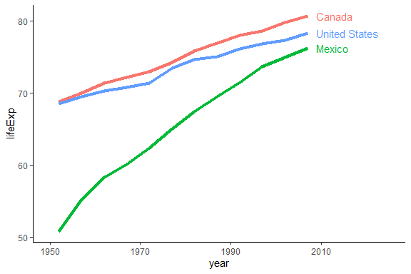

```r
p <- gapminder %>%
  group_by(country) %>%
  mutate(country_label = ifelse(year == max(year), as.character(country), NA_character_)) %>%
  filter(country %in% c('United States','Canada','Mexico')) %>%
  ggplot(aes(x = year, y = lifeExp, color=country)) + geom_line(size = 1.5) +
  scale_x_continuous(limits = c(1950,2025))+ theme_classic()+guides(color='none')+
  geom_text(aes(x = year + 2,label = country_label), hjust = 0)
p
```

## Overall Annotation

- You can use the regular **ggplot2** `annotate()` function, but this takes some work
- **ggannotate** will let you work hands-on with it, and it gives you code at the end
- Also works for adding lines and arrows
- The `geom_mark` functions from **ggforce** are good for shape highlights ([here](https://ggforce.data-imaginist.com/reference/geom_mark_circle.html))
- Excel-esque but the end result is more rigorous
- Install with `remotes::install_github` `("mattcowgill/ggannotate")`, not `install.packages()`

## ggannotate

- Let’s see what happens when we run this…

```r
# Remember we created p a few slides ago
ggannotate::ggannotate(p)
```

## ggannotate

- We get code chunks to add to our graph to get our annotations

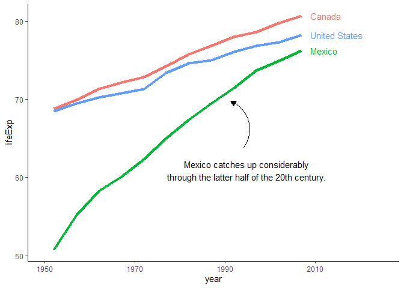

## Export

- Alright, we’ve crafted our perfect graph
- What do we do now?
- `ggsave()` will save our result to file (or we can Export Image in the Plots frame of RStudio)
- But we have some more options still!

## Sticking Graphs Together

- If you have multiple plots that go together, consider using **patchwork** to put them all into one
- With the library loaded, you can just add plots together and they get stitched!
- Let’s stitch together some of the plots from this presentation
- `+` to stick together, `|` to put “beside”, `-` to move to next column, `/` for the next row

## Patchwork

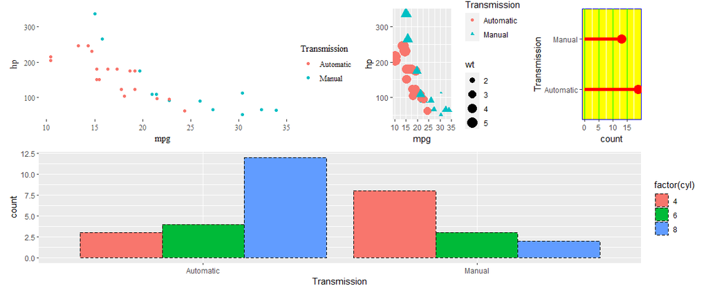

```r
library(patchwork)
# Named and saved these earlier
(p1 | p2 - p3)/p4
```

## Practice

- We may not have time today to practice much of this
- But I want you to take a basic graph, a real basic one, like this:
- `ggplot(mtcars, aes(x = mpg, y = hp)) +` `geom_point()`
- And just see how you can make it look. Mess around with it
- The only goal is to try stuff out.